# another experiment

Evangeline Reynolds

2026-08-01

## Status Quo

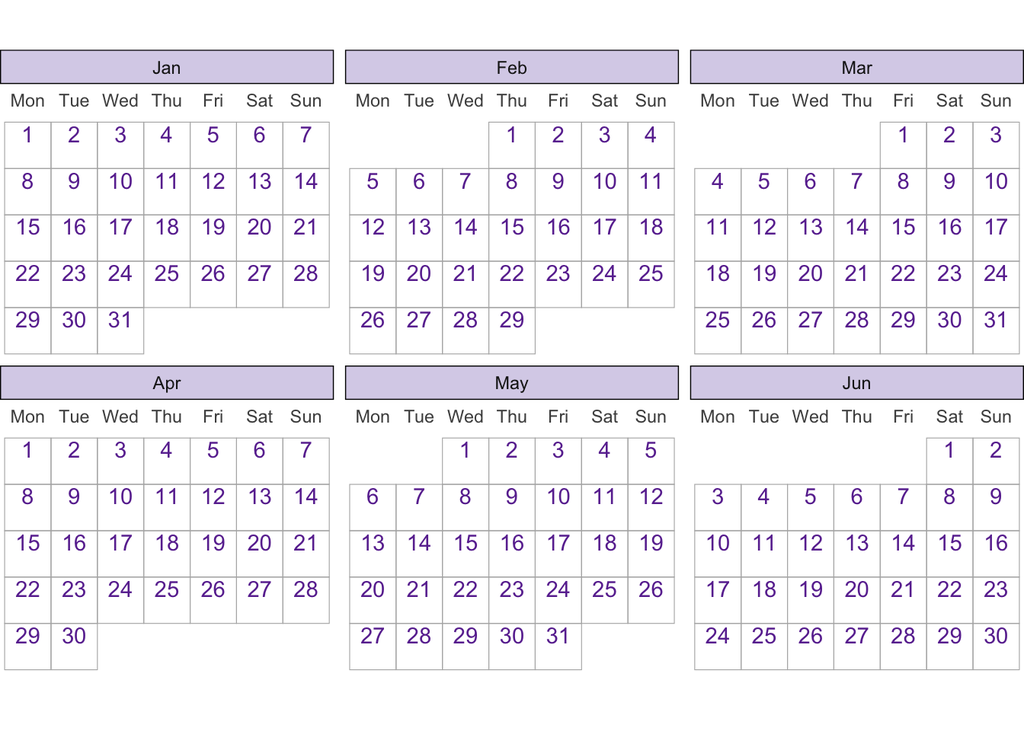

```r
library(tidyverse)

library(ggplot2)
library(ggtilecal)
make_empty_month_days(c("2024-01-05", "2024-06-30")) |>
  gg_facet_wrap_months(unit_date,
                       .geom = list(
                         geom_tile(color = "grey70",
                                   fill = "transparent"),
                         geom_text(nudge_y = 0.25,
                                   color = "#6a329f")),
                       .theme = list(
                         theme_bw_tilecal(),
                         theme(strip.background = element_rect(fill = "#d9d2e9")))
                       )
```

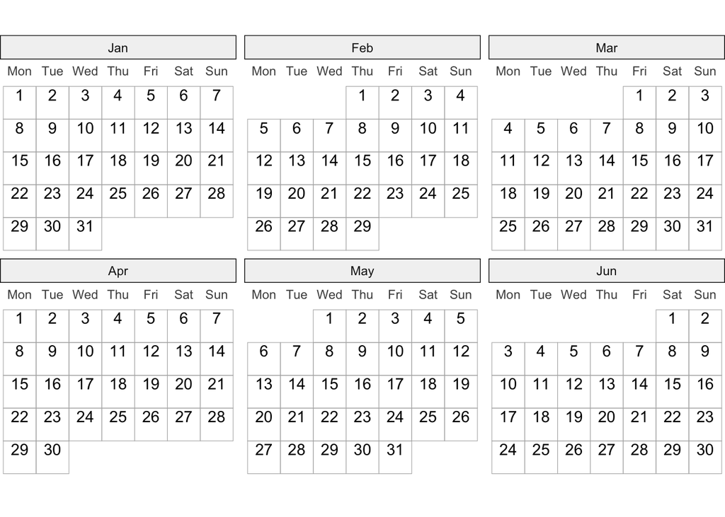

```r
make_empty_month_days(c("2024-01-05", "2024-06-30")) |>
  gg_facet_wrap_months(unit_date)
```

```r
args(gg_facet_wrap_months)
```

```
## function (.events_long, date_col, locale = NULL, week_start = NULL,
##     nrow = NULL, ncol = NULL, .geom = list(geom_tile(color = "grey70",
##         fill = "transparent"), geom_text(nudge_y = 0.25)), .scale_coord = list(scale_y_reverse(),
##         scale_x_discrete(position = "top"), coord_fixed(expand = TRUE)),
##     .theme = list(theme_bw_tilecal()), .other = list())
## NULL
```

```r
body(gg_facet_wrap_months)
```

```
## {
##     cal_data <- calc_calendar_vars(fill_missing_units(.events_long,
##         {
##             {
##                 date_col
##             }
##         }), {
##         {
##             date_col
##         }
##     })
##     base_plot <- ggplot2::ggplot(cal_data, mapping = aes_string(x = "TC_wday_label",
##         y = "TC_month_week", label = "TC_mday")) + facet_wrap(c("TC_month_label"),
##         axes = "all_x", nrow = nrow, ncol = ncol) + labs(y = NULL,
##         x = NULL) + .geom + .scale_coord + .theme + .other
##     base_plot
## }
```

```r
gg_facet_wrap_months <- function(...){
  ## Data Helpers
  cal_data <- .events_long |>
    fill_missing_units({{ date_col }}) |>
    calc_calendar_vars({{ date_col }})

  ## Plot Construction
  base_plot <- cal_data |>
    ggplot2::ggplot(mapping = aes_string(
      x = "TC_wday_label",
      y = "TC_month_week",
      label = "TC_mday"
    )) +
    facet_wrap(c("TC_month_label"), axes = "all_x", nrow = nrow, ncol = ncol) +
    labs(y = NULL, x = NULL) +
    .geom +
    .scale_coord +
    .theme +
    .others

  base_plot
}
```

#### Plot Helper Interface

```r
gg_facet_wrap_months(
  .events_long,
  date_col,
  locale = NULL,
  week_start = NULL,
  nrow = NULL,
  ncol = NULL,
  .geom = list(
    geom_tile(color = "grey70", fill = "transparent"),
    geom_text(nudge_y = 0.25)
  ),
  .scale_coord = list(
    scale_y_reverse(),
    scale_x_discrete(position = "top"),
    coord_fixed(expand = TRUE)),
  .theme = list(theme_bw_tilecal()),
  .other = list()
)
```

[output not shown]

The component list arguments are initialised with sensible defaults, and inherit aesthetic mappings from the “fixed” internal components. The “fixed” components are the “improper” part of the solution, as they could probably be replaced by new `ggplot2` Stat and Facet objects.

### Internals: Data then Plot

List arguments bind together user inputs that all go into the same place inside the helper function (e.g. elements in `.geom` are added before `.scale_coord`, which comes before `.theme` and the final the catch-all `.other`). This design allow users to leverage the consistent syntax `ggplot2` when specifying customisations. The user specified `ggplot2` components are passed directly into the ggplot building portion of the helper function, avoiding the need for ad-hoc and plot-specific customisation arguments.

#### Plot Helper Body

```r
gg_facet_wrap_months <- function(...){
  ## Data Helpers
  cal_data <- .events_long |>
    fill_missing_units({{ date_col }}) |>
    calc_calendar_vars({{ date_col }})

  ## Plot Construction
  base_plot <- cal_data |>
    ggplot2::ggplot(mapping = aes_string(
      x = "TC_wday_label",
      y = "TC_month_week",
      label = "TC_mday"
    )) +
    facet_wrap(c("TC_month_label"), axes = "all_x", nrow = nrow, ncol = ncol) +
    labs(y = NULL, x = NULL) +
    .geom +
    .scale_coord +
    .theme +
    .others

  base_plot
}
```

The example below shows an example customisation using the component arguments:

```r
library(ggplot2)
library(ggtilecal)
make_empty_month_days(c("2024-01-05", "2024-06-30")) |>
  gg_facet_wrap_months(unit_date,
                       .geom = list(
                         geom_tile(color = "grey70",
                                   fill = "transparent"),
                         geom_text(nudge_y = 0.25,
                                   color = "#6a329f")),
                       .theme = list(
                         theme_bw_tilecal(),
                         theme(strip.background = element_rect(fill = "#d9d2e9")))
                       )
```

[output not shown]

[output not shown]

This design also supports using geoms from other packages without depending on those packages directly, (i.e. `ggiraph` is not a dependency of `ggtilecal`). Additional layers can be included in the `.geom`, or added as normal using `+`:

```r
# remotes::install_github("cynthiahqy/ggtilecal")
library(ggiraph)
library(ggplot2)
library(ggtilecal)

gi <- demo_events_gpt |>
    reframe_events(startDate, endDate) |>
  gg_facet_wrap_months(unit_date) +
  geom_text(aes(label = event_emoji), nudge_y = -0.25, na.rm = TRUE) +
  geom_tile_interactive(
        aes(
            tooltip = paste(event_title),
            data_id = event_id
        ),
        alpha = 0.2,
        fill = "transparent",
        colour = "grey80"
    )
```

[output not shown]

[output not shown]

```r
girafe(ggobj = gi)
```

[output not shown]

[output not shown]

### Documentation: Exposing Internal Workings

In addition to exposing the `ggplot2` components as list arguments, I also document the data preparation steps that the plot helper function is performing:

```r
#' Make Monthly Calendar Facets
#'
#' Generates calendar with monthly facets by:
#' - Padding event list with any missing days via `fill_missing_units()`
#' - Calculating variables for calendar layout via `calc_calendar_vars()`
#' - Returning a ggplot object as per Details.
```

and how the ggplot2 recipe works:

```r
#' Returns a ggplot with the following fixed components using calculated layout variables:
#' - `aes()` mapping:
#'    - `x` is day of week,
#'    - `y` is week in month,
#'    - `label` is day of month
#' - `facet_wrap()` by month
#' - `labs()` to remove axis labels for calculated layout variables
#'
#' and default customisable components:
#' - `geom_tile()`, `geom_text()` to label each day which inherit calculated variables
#' - `scale_y_reverse()` to order day in month correctly
#' - `scale_x_discrete()` to position weekday labels
#' - `coord_fixed()` to square each tile
#' - `theme_bw_tilecal()` to apply sensible theme defaults
#'
```

and how to modify the plot:

```r
#' To modify components alter the `.geom` and `.scale_coord`,
#' which inherit the calculate layout mapping by default
#' (via the ggplot2 `inherit.aes` argument).
#'
#' To add components use the ggplot `+` function as normal,
#' or pass components to the `.other` argument.
#' This can be used to add interactive geoms (e.g. from `ggiraph`)
#'
#' To modify the theme, use the ggplot `+` function as normal,
#' or add additional elements to the list in `.theme`.
#'
#' To remove any of the optional components,
#' set the argument to any empty `list()`
```

## Design Principles for `ggplot2` Plot Helpers

To summarise my opinionated take on how you should write plot helper functions:

- Writing plot helper functions is an appealling solution for reusing long / complex `ggplot2` recipes.
- However, if not well designed and scoped, plot helper functions that “save” code lines in the short-term, can explode into highly specific and difficult to use custom interfaces in the long-term.
- To avoid reimplementing “saved” code lines as plot-specific arguments, when writing a plot helper consider:
  - exposing plot components as list arguments with sensible defaults,
  - calling separately defined data helpers before constructing the final plot,
  - fully documenting the internal workings of the function.